# *T* chimera: Cell Quality Control

C. Guibentif, J. Griffiths et al. _T_ Chimera

21 October 2019

# Contents

```r
library(Matrix)
library(biomaRt)
library(ggplot2)
library(knitr)
library(scales)
library(viridis)
library(cowplot)

#core functions inc. colour palette
source("/nfs/research1/marioni/jonny/chimera-t/scripts/core_functions.R")


counts = readMM("/nfs/research1/marioni/jonny/chimera-t/data/raw_counts.mtx")
genes = read.table("/nfs/research1/marioni/jonny/chimera-t/data/genes.tsv", stringsAsFactors = F)
barcodes = read.table("/nfs/research1/marioni/jonny/chimera-t/data/barcodes.tsv", stringsAsFactors = F)[,1]
exp_design = read.table("/nfs/research1/marioni/jonny/chimera-t/raw/meta/exp_design.csv", sep = ",", header = TRUE)
```

# 1 Comparing sequencing saturation

The 10X system uses unique molecular identifiers (UMIs). By considering how frequently the same UMIs have been sequenced, the saturation of sequencing can be estaimted (i.e. what % of captured molecules have been sequenced). Sample-wise median UMI counts are plotted alongside the sequencing saturations estimated by CellRanger in Figure 1.

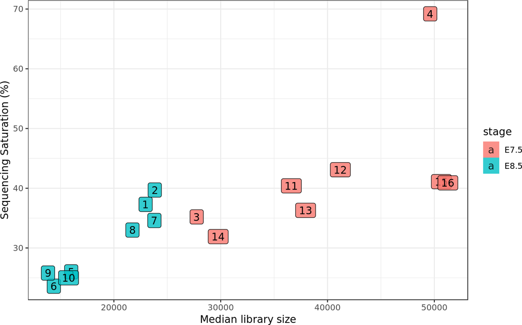

Figure 1: Sequencing saturations for each sample

```r
lib.sizes = colSums(counts)

split_bc = strsplit(as.character(barcodes), "-", fixed = T)
samples = sapply(split_bc, function(x) x[2])

pdf = data.frame(sample = seq_along(unique(exp_design$sample)),
                 med_lib = sapply(seq_along(unique(exp_design$sample)), function(x) median(lib.sizes[samples == x])),
                 mean_lib = sapply(seq_along(unique(exp_design$sample)), function(x) mean(lib.sizes[samples == x])),
                 stage = sapply(seq_along(unique(exp_design$sample)), function(x) exp_design$stage[match(x, exp_design$sample)]),
                 saturation = sapply(seq_along(unique(exp_design$sample)), function(x){
                   tab = read.table(paste0("/nfs/research1/marioni/jonny/chimera-t/cellranger_out/sample_",
                                                                         x,
                                                                         "/outs/metrics_summary.csv"),
                                    header = TRUE,
                                    sep = ",")
                   stat = tab[1, "Sequencing.Saturation"]
                   return(as.numeric(substr(stat, 1, 4)))
                 }))

ggplot(pdf, aes(x = med_lib, y = saturation, label = seq_along(unique(exp_design$sample)), fill = stage)) +
  geom_label(alpha = 0.8) +
  labs(x = "Median library size", y = "Sequencing Saturation (%)") +
  theme_bw()
```

```r
plot_change = function(barcodes, logical_keep){
  split_bc = strsplit(as.character(barcodes), "-", fixed = T)
  samples = sapply(split_bc, function(x) x[2])

  pdf = data.frame(Sample = unique(samples),
                   Total = sapply(unique(samples), function(x) sum(samples == x)),
                   Dropped = sapply(unique(samples), function(x) sum(!logical_keep[samples == x])),
                   Retained = sapply(unique(samples), function(x) sum(logical_keep[samples == x])))

  p = ggplot(data = pdf) +
          geom_bar(mapping = aes(y = Total,
                                 x = factor(Sample, levels = unique(samples))),
                   fill = "darkgrey",
                   stat = "identity") +
          geom_bar(mapping = aes(y = Retained,
                                 x = factor(Sample, levels = unique(samples))),
                   fill = "coral",
                   stat = "identity") +
          geom_segment(mapping = aes(y = Total,
                                     yend = Retained,
                                     x = factor(Sample, levels = unique(samples)),
                                     xend = factor(Sample, levels = unique(samples))),
                       arrow = arrow(length = unit(0.1, "inches"))) +
          theme_bw() +
          labs(y = "Number of cells", x= "Sample")

  pdf = rbind(pdf, data.frame(Sample = "Total",
                              Total = length(barcodes),
                              Dropped = sum(!logical_keep),
                              Retained = sum(logical_keep)))

  return(list(plot = p, df = pdf))
}
```

# 2 Mitochondrial gene expression

Another useful QC metric is mitochondrial gene fraction: high measurements of mitochrondrial gene expression may indicate stressed cells, or incomplete lysis.

To identify a threshold for cell exclusion, we assume that the “standard” set of mitchondrial UMI fractions can be modelled by a normal distribution. We centre this distribution on the median value, with median absolute deviation estimated variance. We then consider cells outlying if their mitochondrial UMI fraction has a corresponding FDR-adjusted $p<0.05$, and exclude these. The cutoff is shown graphically in Figure 2, with quantification of cell exclusion in Figure 3 and Table 1

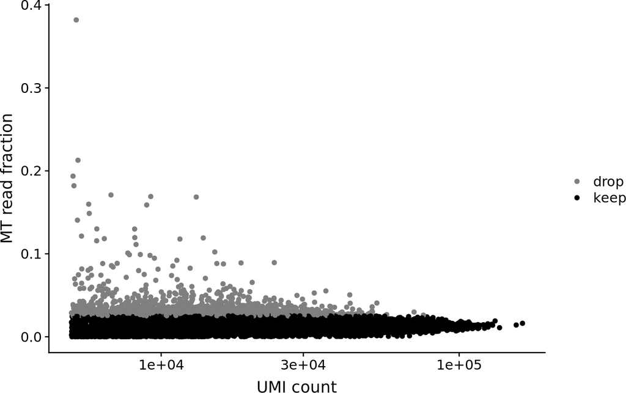

Figure 2: Mitochondrial read fractions

```r
lib.sizes = colSums(counts)

mouse_ensembl = useMart("ensembl", host = "http://apr2018.archive.ensembl.org")
mouse_ensembl = useDataset("mmusculus_gene_ensembl", mart = mouse_ensembl)

gene_map = getBM(attributes=c("ensembl_gene_id", "chromosome_name"), filters = "ensembl_gene_id", values = genes[,1], mart = mouse_ensembl)
mt.counts = counts[which(genes[,1] %in% gene_map$ensembl_gene_id[gene_map$chromosome_name=="MT"]),]
mt.fraction = colSums(mt.counts)/lib.sizes

#fit median-centered, MAD-variance normal
#crass 5%+
# mt.lim = qnorm(0.95, mean = median(mt.fraction), sd = mad(mt.fraction))
#fdr-corrected outliers
#technically this should be a pt, but the df. is astronomically high so this is essentially the same
mt.p = pnorm(mt.fraction, mean = median(mt.fraction), sd = mad(mt.fraction), lower.tail = FALSE)
mt.lim = min(mt.fraction[which(p.adjust(mt.p, method = "fdr") < 0.05)])

qplot(lib.sizes, mt.fraction, col = ifelse(mt.fraction>mt.lim, "drop", "keep")) +
  scale_x_log10() +
  labs(x = "UMI count", y = "MT read fraction") +
  scale_color_manual(values = c("drop" = "grey50", "keep" = "black"), name = "")
```

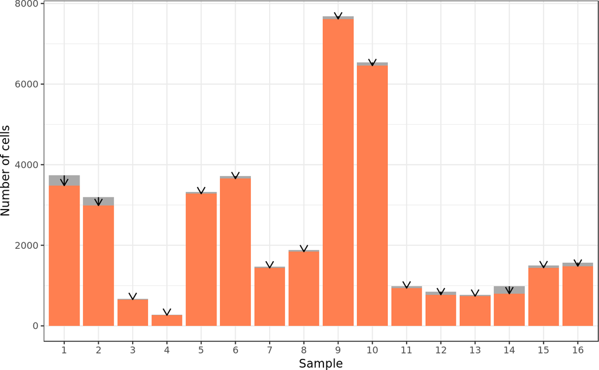

Figure 3: Cells dropped according to mitochondrial fraction threshold

```r
mt_drop = plot_change(barcodes, logical_keep = mt.fraction<mt.lim )

print(mt_drop$plot)
```

```r
kable(mt_drop$df, caption = "Cells dropped according to mitochondrial fraction threshold", row.names = FALSE)
```

Table 1: Cells dropped according to mitochondrial fraction threshold

| Sample | Total | Dropped | Retained |
| --- | --- | --- | --- |
| 1 | 3735 | 254 | 3481 |
| 2 | 3194 | 207 | 2987 |
| 3 | 668 | 13 | 655 |
| 4 | 278 | 14 | 264 |
| 5 | 3323 | 43 | 3280 |
| 6 | 3715 | 61 | 3654 |
| 7 | 1472 | 33 | 1439 |
| 8 | 1883 | 42 | 1841 |
| 9 | 7687 | 70 | 7617 |
| 10 | 6540 | 81 | 6459 |
| 11 | 983 | 44 | 939 |
| 12 | 851 | 78 | 773 |
| 13 | 772 | 35 | 737 |
| 14 | 982 | 184 | 798 |
| 15 | 1494 | 50 | 1444 |
| 16 | 1572 | 90 | 1482 |
| Total | 39149 | 1299 | 37850 |

```r
counts = counts[, mt.fraction < mt.lim]
barcodes = barcodes[mt.fraction < mt.lim]
mt.fraction = mt.fraction[mt.fraction < mt.lim]
```

The cutoff was at 2.52%

# 3 Number of detected genes

The relationship between the number of UMIs per cell and the number of detected genes per cell is shown in Figure 4. Note that these are well behaved between samples.

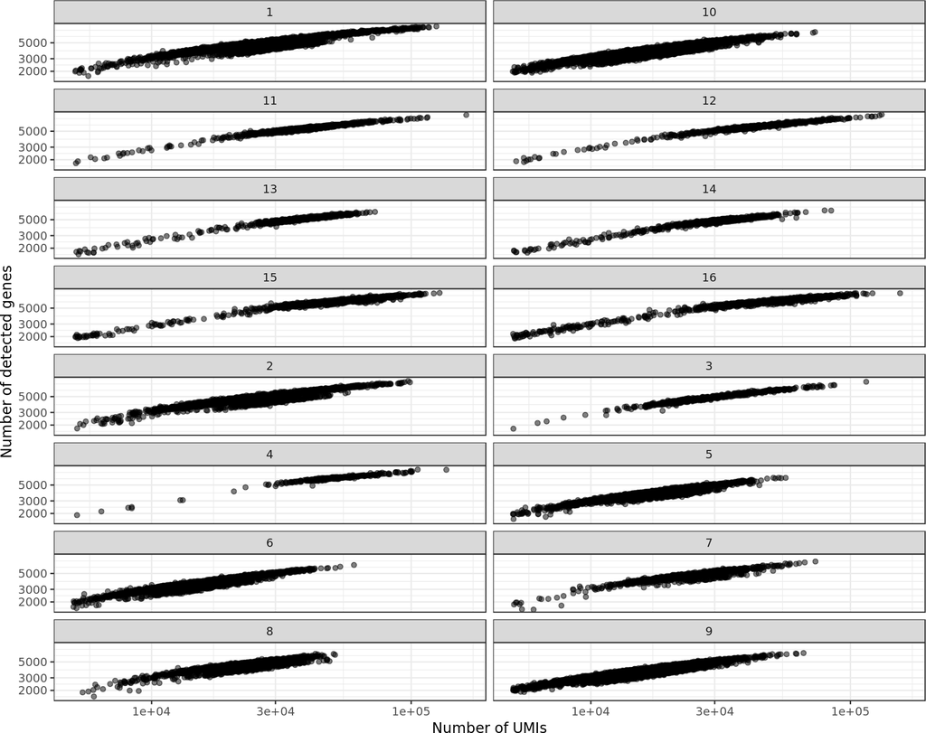

Figure 4: Sample-wise plots of retained libraries

```r
lib.sizes = colSums(counts)
n.genes = colSums(counts>0)

split_bc = strsplit(as.character(barcodes), "-", fixed = T)
bcs = sapply(split_bc, function(x) x[1])
samples = sapply(split_bc, function(x) x[2])

plot_df = data.frame(lib = lib.sizes, genes = n.genes, sample = samples)
plot_df = plot_df[sample(nrow(plot_df), nrow(plot_df), replace = FALSE),]

p = ggplot(plot_df, aes(x = lib, y = genes)) +
  geom_point(alpha = 0.5) +
  scale_colour_Publication() +
  scale_y_log10() +
  scale_x_log10() +
  theme_bw() +
  facet_wrap(~factor(sample, levels = unique(sample)[order(unique(sample))]), ncol = 2) +
  labs(x = "Number of UMIs", y = "Number of detected genes")

suppressWarnings(plot(p))
```

# 4 Inter-sample comparisons

The distributions of UMI counts (Figure 5) and mitchondrial read fractions (Figure 6) are shown between the samples, below.

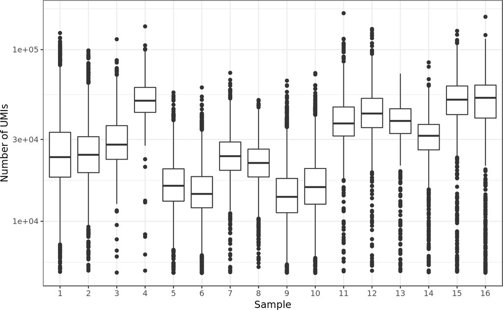

Figure 5: Sample-wise UMI count distributions

```r
p = ggplot(data.frame(lib = lib.sizes, sample = samples), aes (x = factor(sample, levels = unique(sample)),
                                                           y = lib.sizes)) +
  geom_boxplot() +
  theme_bw() +
  scale_y_log10() +
  labs(x = "Sample", y = "Number of UMIs")

suppressWarnings(plot(p))
```

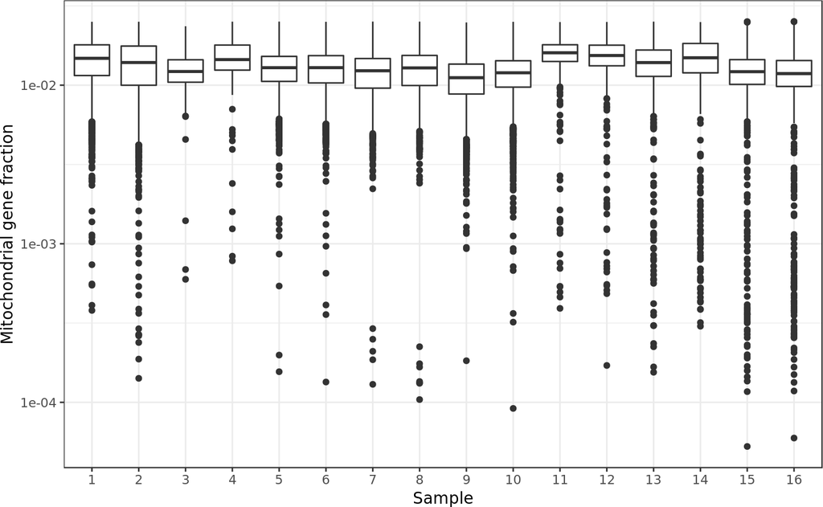

Figure 6: Sample-wise mitochrondrial UMI distributions

```r
p = ggplot(data.frame(mt = mt.fraction, sample = samples), aes (x = factor(sample, levels = unique(sample)),
                                                           y = mt)) +
  geom_boxplot() +
  theme_bw() +
  scale_y_log10() +
  labs(x = "Sample", y = "Mitochondrial gene fraction")

suppressWarnings(plot(p))
```

# 5 Make meta

We now save the metadata, recording for each cell its barcode, sample, and developmental stage.

```r
split_bc = strsplit(as.character(barcodes), "-", fixed = T)
bcs = sapply(split_bc, function(x) x[1])
samples = sapply(split_bc, function(x) x[2])

meta = data.frame(cell = paste0("cell_", 1:ncol(counts)),
                  barcode = bcs,
                  sample = samples,
                  stage = exp_design$stage[match(samples, exp_design$sample)],
                  tomato = as.logical(as.numeric(samples)%%2),
                  pool = ceiling(as.numeric(samples)/2))
```

Finally, we have 37850 cells, Distributed between samples and stages as shown in Table 2.

```r
tab = as.matrix(table(meta$sample, meta$stage))

new_rownames = c("Total", rownames(tab))
tab = rbind(sapply(colnames(tab), function(x) sum(meta$stage == x)),
            tab)
rownames(tab) = new_rownames

pt = kable(tab, caption = "Number of cells retained for analysis")
pt
```

Table 2: Number of cells retained for analysis

|  | E7.5 | E8.5 |
| --- | --- | --- |
| Total | 7092 | 30758 |
| 1 | 0 | 3481 |
| 10 | 0 | 6459 |
| 11 | 939 | 0 |
| 12 | 773 | 0 |
| 13 | 737 | 0 |
| 14 | 798 | 0 |
| 15 | 1444 | 0 |
| 16 | 1482 | 0 |
| 2 | 0 | 2987 |
| 3 | 655 | 0 |
| 4 | 264 | 0 |
| 5 | 0 | 3280 |
| 6 | 0 | 3654 |
| 7 | 0 | 1439 |
| 8 | 0 | 1841 |
| 9 | 0 | 7617 |

# 6 Save data

```r
holder = writeMM(counts, file = "/nfs/research1/marioni/jonny/chimera-t/data/raw_counts.mtx")
saveRDS(as(counts, "dgCMatrix"), file = "/nfs/research1/marioni/jonny/chimera-t/data/raw_counts.rds")
write.table(barcodes, file = "/nfs/research1/marioni/jonny/chimera-t/data/barcodes.tsv", row.names = F, col.names = F, quote = F, sep = "\t")
write.table(meta, file = "/nfs/research1/marioni/jonny/chimera-t/data/meta.tab", row.names = F, col.names = T, quote = F, sep = "\t")
```